F(x)

# Md Polash *Ali*

Statistician, researcher, and a fairly consistent believer in the fitted line.

I'm a Ph.D. student in the Department of Mathematics & Statistics at the University of South Florida (USF), working across biostatistics, public health, spatial epidemiology, and machine learning, usually somewhere between a public-health dataset and a model that refuses to converge.

7 manuscripts · 2 published TA, USF Math & Stats Tampa ← Dhaka ← Chapainawabganj

Get in touch See the research

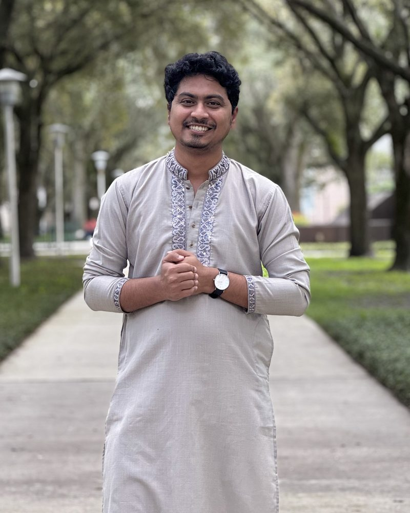

About

## The short version

I grew up in **Chapainawabganj**, a district in Rajshahi Division known across Bangladesh for its sweet mangoes, something the people of my hometown take great pride in. I went through my secondary years at **Harimohan Government High School** and higher secondary at **Nawabganj Government College**, before moving to the **University of Dhaka** to study Statistics.

Today, I'm a Ph.D. student at the **University of South Florida (USF)**, where I research statistics with a growing interest in its applications to public health. My goal is to bring statistics and public health together to contribute, in my own way, to a healthier and better society.

I'm the elder brother of twin sisters, and however far Tampa is from Chapainawabganj, I still measure a good year partly by how the mango season went back home.

Off the clock, I'm usually three episodes into a thriller or quietly relitigating whether Spider-Man's instincts beat Iron Man's engineering. I haven't fully decided.

**Home**

Chapainawabganj, Rajshahi, Bangladesh

**Based in**

Tampa, Florida, USA

**Field**

Biostatistics, Public Health, Spatial Epidemiology

**Family**

Elder brother to twin sisters; parents back home

**Languages**

Bengali, English, Hindi

Education & Experience

## Six steps, one direction

From two schools in Chapainawabganj to a Ph.D. program in Tampa, with a couple of applied biostatistics roles along the way.

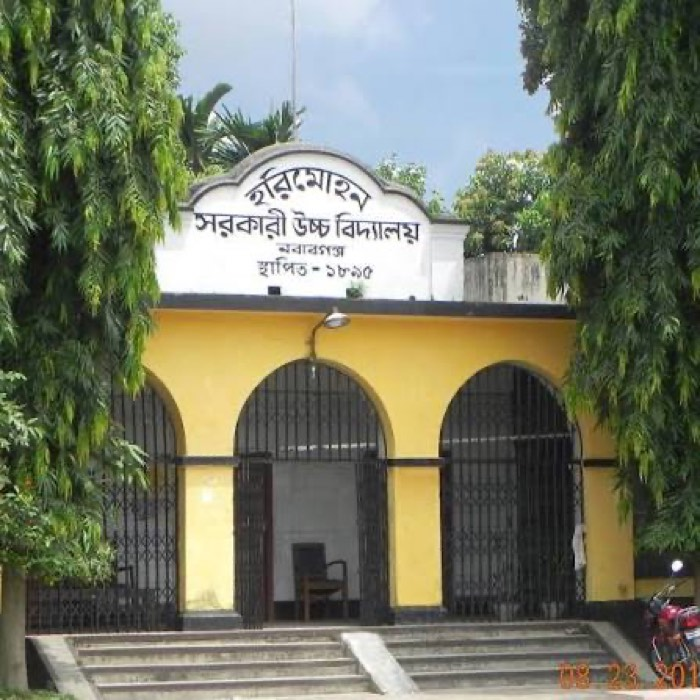

### Secondary Education

[Harimohan Government High School↗](https://harimohanschool.edu.bd/)

Chapainawabganj, Bangladesh

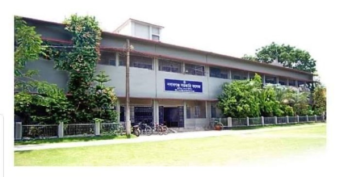

### Higher Secondary Education

[Nawabganj Government College↗](https://www.ngcc.edu.bd/en)

Chapainawabganj, Bangladesh

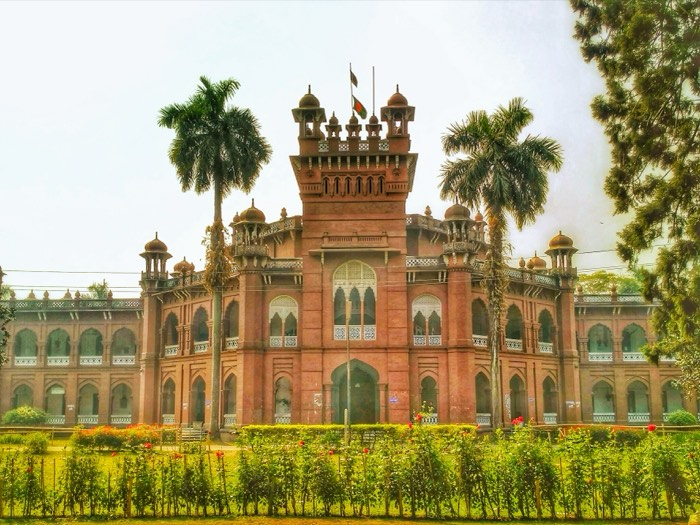

### Undergraduate Degree

[University of Dhaka↗](https://www.du.ac.bd/)

B.S., Statistics

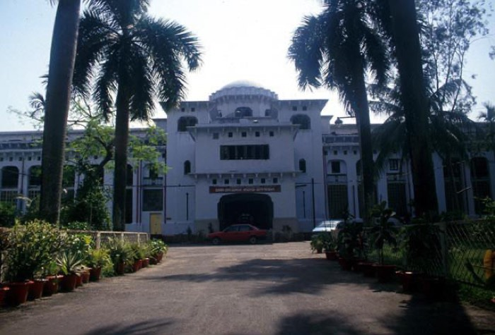

### Biostatistics Trainer

[Dhaka Medical College & Hospital↗](https://dmch.gov.bd/)

Department of Hepatology

[figure not shown]

### Data Consultant

[FHI-360 Bangladesh↗](https://www.fhi360.org/countries/bangladesh/)

Spatial analysis for TB surveillance across districts.

[figure not shown]

### Ph.D. Student + Teaching Assistant

[University of South Florida↗](https://www.usf.edu/)

Recitations, office hours, and course logistics.

Research & Publications

## What I've been testing

Statistics in public health research spanning substance use, food insecurity, autism spectrum disorder, and community mental health, along with the export-forecasting paper that started my research journey.

Biostatistics & Public Health Applied Statistics Time Series Analysis Machine Learning Spatial Epidemiology Statistical Genetics & Causal Inference

2

Published papers

2

Under review

3

In preparation

2

Conference talks & posters

### Published Journal Articles

- **Ali, M.P.**, Sadia, A.Z., & Khanam, M. (2025). [ARIMA vs. ETS for RMG Export Forecasting of Bangladesh: A Comparative Study on Model Accuracy.](https://doi.org/10.3329/dujs.v73i2.82767)

  Dhaka University Journal of Science · 73(2), 101–105
- Ahmmad, M.R., **Ali, M.P.**, Ukpong, I., & Pantazopoulos, H. (2026). [Sugar-sweetened beverage intake, food affordability, and autism spectrum disorder among young U.S. children: A national survey analysis.](https://doi.org/10.1016/j.cegh.2026.102494)

  Clinical Epidemiology and Global Health · 42, 102494

### Under Review Journal Articles

- Ahmmad, M.R., **Ali, M.P.**, & Faruque, F. (2026). Co-Occurring Substance Use and Mental Health Disorders Among Educated Adults Experiencing Homelessness in the United States: A Spatiotemporal and Machine-Learning Analysis.

  RSPH Public Health
- Ahmmad, M.R., **Ali, M.P.**, Mazumder, S., & Khan, M.T.F. (2026). Differential Associations Between Psychiatric Multimorbidity and Substance Use Disorders Among Unemployed U.S. Veterans.

  Health Science Reports

### In Preparation Manuscripts

- **Ali, M.P.**, Ukpong, I., & Ahmmad, M.R. (2026). Differential Associations Between Higher Birth Order and Autism Spectrum Disorder with Family Dynamics Among African-American Children.
- Ahmmad, M.R., **Ali, M.P.**, Rossiter, A., Faruque, F., & Zhang, X. (2026). Addiction and Co-occurring Multiple Mental Health Disorders Among Unemployed U.S. Veterans: A Spatiotemporal Analysis, 2017–2023.
- Ahmmad, M.R., **Ali, M.P.**, & Khan, M.T.F. (2026). Household Food Insecurity and Co-occurring Autism and Behavior or Conduct Disorders in U.S. Children: Evidence from Spatiotemporal Hierarchy and Machine Learning Analyses.

### Presented Conferences & Abstracts

- Ahmmad, M.R., Khan, M.T.F., Faruque, F., **Ali, M.P.**, & Zhang, X. (2026). [A Community-level Mental Health Burden Index: Development, Validation and Spatial Vulnerability.](https://ww2.amstat.org/meetings/jsm/2026/onlineprogram/abstract.cfm?sid=6997&tid=7706)

  Joint Statistical Meetings 2026 · Presented
- Ukpong, I., **Ali, M.P.**, Pantazopoulos, H., & Ahmmad, M.R. (2026). Frequency Patterns of Sugar-Sweetened Beverage Intake and Autism.

  USF Research Day · Poster #132

[figure not shown]

Research Projects

## From question to evidence

Applied research projects, with summaries and supporting materials.

Project 01 · Fall 2025

### Quantifying the Influence of Socioeconomic and Public Health Predictors on Life Expectancy

This study examines how socioeconomic conditions and public health burdens relate to life expectancy across 183 countries in 2015. Multiple linear regression was used to estimate the independent associations of candidate predictors, assess multicollinearity, and select a more parsimonious model through backward stepwise regression.

Multiple linear regressionExploratory data analysisMulticollinearity diagnosticsBackward stepwise selectionR

**183**countries observed in 2015

**0.8715**adjusted R² for the final model

**7**predictors retained in the final model

- Average years of schooling had the strongest positive association in the final model: about 0.70 additional years of life expectancy per additional year of schooling, holding the other model variables constant.
- Adult mortality, HIV death rate, early-childhood thinness, polio immunization deficit, and developing-country status were negatively associated with life expectancy; log GDP per capita was positively associated.
- The final model retained schooling, log GDP per capita, adult mortality, log HIV death rate, log early-childhood thinness, log polio immunization deficit, and country status.

The findings describe adjusted associations in cross-sectional country-level data; they should not be interpreted as causal effects.

**Data & Scripts**

- Life Expectancy Data.xlsx Project dataset
- Scratch Paper.R Exploratory analysis and transformations
- LE project2.R Regression model development

Project Report

Project 02 · Spring 2026 · STA 6167

### Regression-Based Bias Correction of Seoul’s LDAPS Temperature Forecasts

This project evaluates whether regression-based post-processing can correct next-day maximum temperature forecasts from the LDAPS numerical weather prediction model. Using summer observations from 25 Seoul weather stations across 2013–2017, the analysis models forecast error as observed temperature minus the raw forecast, then applies the estimated correction to the forecast.

Exploratory data analysisAIC stepwise selectionWeighted least squaresBias correctionR

**+0.621°C**mean raw forecast bias (cold)

**1.709 → 1.504°C**RMSE before and after correction

**0.698 → 0.766**R² before and after correction

- The final weighted regression model used 27 parameters to estimate forecast bias; its test-set bias-prediction RMSE was 1.516°C.
- Across the full study sample, bias correction reduced the mean forecast error from +0.621°C to −0.033°C and reduced RMSE by about 12%.
- The analysis is limited to Seoul summers. Its random train/test split includes the same stations and study years on both sides, and residual diagnostics indicate some nonlinearity remains.

Results are observational and describe forecast performance in this dataset; they do not establish performance for other regions or seasons.

**Data & Scripts**

- temp.csv Analysis dataset
- Final Rcodes.Rmd Reproducible analysis and model development

Project Report Presentation Project Video

Recognition

## Awards, credentials & service

### Awards & Honors

- Winner: QMH Statistics Club Data Analysis CompetitionUniversity of Dhaka, 2025
- Dutch Bangla Bank ScholarshipMerit-based national scholarship, HSC Batch 2018

### Certifications & Training

- Python for Everybody SpecializationUniversity of Michigan, 2020
- Excel Skills for Business SpecializationMacquarie University, 2020
- Data Analysis & Visualization FoundationsGoogle, 2020

### Leadership & Service

- General Secretary, GOURDhaka University Students' Association of Chapainawabganj, 2023–2024
- Vice-President, PREDICTORSFH Hall Statisticians Organization, University of Dhaka, 2024–2025
- Active Member, QMH Statistics ClubUniversity of Dhaka, 2024–2025

Every team needs someone willing to run the meeting. Call it a little Captain America energy.

### Languages

Bengali NATIVE

English FLUENT

Hindi CONVERSATIONAL

Toolkit

## What I build with

The languages, software, and mapping tools the research above runs on, stretched Reed Richards style across a fairly wide stack.

### Programming Languages

R Python SQLSQL C SASSAS

### Statistical Software

IBM SPSS STASTATA MTBMinitab

### GIS & Spatial Analysis

ArcGIS Pro QGIS

### Data Visualization & Docs

ggggplot2 Tableau Microsoft Excel LaTeX

Off the Clock

## Beyond the numbers

A few variables the CV doesn't have a column for.

Marvel

### Spider-Man & Iron Man

When a problem gets tangled, it's a toss-up between a web-slinger's instinct for finding the pattern in chaos and a genius engineer's habit of just building something better. Still haven't picked a side. (Every dataset has one Hulk-sized outlier, too, and a truly stubborn model earns a bit of Thor commentary about which one is actually worthy.)

Weekend Ritual

### Cricket

Bat, ball, and a good over: cricket is the constant that travels well, whether the pitch is in Dhaka or a park in Tampa.

On Replay

### Thrillers & Adventures

My favorite kind of plot twist is basically a p-value: the moment everything you assumed gets rejected.

Wanderlust

### Traveling

Home base is Tampa, but the map keeps growing: new cities, new campuses, and new food to compare (fairly) to a plate back home.

Get in Touch

## Let's talk data (or Spider-Man vs. Iron Man).

Open to research collaborations, teaching conversations, and anyone who wants to argue about a fitted model.

ali75@usf.edu Download CV (PDF)

[ResearchGateMd-Polash-Ali-2](https://www.researchgate.net/profile/Md-Polash-Ali-2) [Google ScholarView publication record](https://scholar.google.com/citations?user=-KJM4OYAAAAJ&hl=en) [LinkedInmd-polash-ali](https://www.linkedin.com/in/md-polash-ali-102aa91ba/) LocationTampa, Florida, USA